# 04 - Genomic selection program, breeder’s equation, index and mating plan

Prepared by Emmanuel Ismaila for QGG, Aarhus University

# 1 What this file does

[output not shown]

The two NUE indices differ from GS_NTM **only in the NUE weight**, so differences in any trait are attributable to that one weight. The earlier illustrative indices (GS_PROD, GS_NUE, GS_NUE_noMUN; superseded) are in `archive_illustrative_index/`.

Genomic EBVs come from **SNP effects** (SNP-BLUP), so EBV = Σ dosage x marker effect. Training is strictly forward: calves are selected before their own (or sisters’) CFIT records exist, matching the pipeline timeline (genotyping year 2, phenotypes from year 4).

Each call runs one replicate (`rep_id`); replicates use seed + `rep_id`, with the same random stream start for every scenario within a replicate, so scenarios are compared **paired**.

# 2 Load burn-in state

```r
st <- readRDS(file.path(params$sim_dir, "burnin_state.rds")); SP <- st$SP
# Memory: only the last two burn-in generations of cows are used below (training set)
st$kept_cows <- st$kept_cows[as.integer(sub(" .*", "", names(st$kept_cows))) >= max(as.integer(sub(" .*", "", names(st$kept_cows)))) - 1]
invisible(gc())
memlog <- function(tag) progress(params$scenarios[1], " ", tag, " | R memory in use (MB): ", round(sum(gc()[, 2])))
memlog("state loaded")
phen0 <- fread(file.path(params$sim_dir, "phenotypes.csv"))
phen0 <- phen0[generation >= max(generation) - 1]          # only the last two burn-in generations are used
trend0 <- fread(file.path(params$sim_dir, "trend_burnin.csv"))
h2 <- fread(if (file.exists(file.path(params$sim_dir, "h2_used.csv"))) file.path(params$sim_dir, "h2_used.csv") else "params/h2.csv")   # h2 of this burn-in (sensitivity sets differ)
split <- fread("params/breed_country_split.csv"); herds_tab <- fread("params/herds.csv")
traits <- st$traits; nT <- length(traits); breeds <- c("HOL", "RDC", "JER")
countries <- unique(split$country); nC <- length(countries)
all_herds <- herds_tab$herd; herd_country <- herds_tab$country
gxe <- st$gxe_rg < 1
n_cow <- round(split[, sum(n), by = breed][match(breeds, breed), V1] * st$design$scale)
names(n_cow) <- breeds
sires_n <- st$design$sires_per_breed
burn_end <- max(phen0$generation)
cat("Start generation:", burn_end, "| cows per breed:", paste(n_cow, collapse = "/"),
    "| sires:", paste(sires_n, collapse = "/"), "| GxE scenario:", gxe, "\n")
```

```
## Start generation: 10 | cows per breed: 12000/8100/8300 | sires: 40/42/60 | GxE scenario: FALSE
```

# 3 Breeding goal and selection indices

Index weights act on **standardised** breeding values (divided by the genetic SD of each trait at the end of burn-in). They are the **NTM sub-index weights (May 2026)**, mapped onto the simulated traits in file 00 (`params/index_weights.csv`), and are **breed-specific**. NUE, MUN, CH4 and LNVAR have no NTM weight; NUE is added at 0.35 or 0.75, MUN at -0.35 and CH4 at -0.50 (file 00). Saved Feed (SF) carries the NTM Saved Feed weight.

```r
iw <- fread("params/index_weights.csv")
ntm_of <- function(s) sub("_(MATE|OCS)$", "", s)          # MATE/OCS use their base index
idx_def <- fread("params/index_definitions.csv")            # indices defined in file 00
all_scen <- c("PHENO", idx_def$index, "GS_NTM_NUE35_MATE", "GS_NTM_NUE35_OCS")
W_idx <- setNames(lapply(all_scen, function(s) {
  base <- if (s == "PHENO") "GS_NTM" else ntm_of(s)
  stopifnot(base %in% iw$index)
  setNames(lapply(breeds, function(b) { x <- iw[index == base & breed == b]; setNames(x$weight, x$trait)[traits] }), breeds)
}), all_scen)
# "CH4_KNEE" = the methane index chosen in file 00 (its name depends on which NUE weight wins the sweep)
scen_req <- ifelse(params$scenarios == "CH4_KNEE", idx_def[ch4 != 0, index][1], params$scenarios)
stopifnot(!anyNA(unlist(W_idx)), all(scen_req %in% all_scen))
kable(idx_def, caption = "Extra weights (per genetic SD) added to the NTM weights, from file 00")
```

Extra weights (per genetic SD) added to the NTM weights, from file 00

| index | nue | mun | ch4 |
| --- | --- | --- | --- |
| GS_NTM | 0.00 | 0.00 | 0.0 |
| GS_NTM_NUE35 | 0.35 | 0.00 | 0.0 |
| GS_NTM_NUE75 | 0.75 | 0.00 | 0.0 |
| GS_NTM_NUE35_MUN | 0.35 | -0.35 | 0.0 |
| GS_NTM_NUE75_CH4 | 0.75 | 0.00 | -0.5 |

```r
kable(dcast(iw[weight != 0 | trait %in% c("NUE", "MUN", "CH4")], trait ~ index + breed, value.var = "weight"), digits = 3,
      caption = "Index weights per genetic SD (all other traits 0)")
```

Index weights per genetic SD (all other traits 0)

| trait | GS_NTM_HOL | GS_NTM_JER | GS_NTM_RDC | GS_NTM_NUE35_HOL | GS_NTM_NUE35_JER | GS_NTM_NUE35_RDC | GS_NTM_NUE35_MUN_HOL | GS_NTM_NUE35_MUN_JER | GS_NTM_NUE35_MUN_RDC | GS_NTM_NUE75_HOL | GS_NTM_NUE75_JER | GS_NTM_NUE75_RDC | GS_NTM_NUE75_CH4_HOL | GS_NTM_NUE75_CH4_JER | GS_NTM_NUE75_CH4_RDC |
| --- | --- | --- | --- | --- | --- | --- | --- | --- | --- | --- | --- | --- | --- | --- | --- |
| CH4 | 0.000 | 0.000 | 0.000 | 0.000 | 0.000 | 0.000 | 0.000 | 0.000 | 0.000 | 0.000 | 0.000 | 0.000 | -0.500 | -0.500 | -0.500 |
| FY | 0.292 | 0.270 | 0.311 | 0.292 | 0.270 | 0.311 | 0.292 | 0.270 | 0.311 | 0.292 | 0.270 | 0.311 | 0.292 | 0.270 | 0.311 |
| ICF | -0.360 | -0.260 | -0.360 | -0.360 | -0.260 | -0.360 | -0.360 | -0.260 | -0.360 | -0.360 | -0.260 | -0.360 | -0.360 | -0.260 | -0.360 |
| LONG | 0.060 | 0.090 | 0.060 | 0.060 | 0.090 | 0.060 | 0.060 | 0.090 | 0.060 | 0.060 | 0.090 | 0.060 | 0.060 | 0.090 | 0.060 |
| MUN | 0.000 | 0.000 | 0.000 | 0.000 | 0.000 | 0.000 | -0.350 | -0.350 | -0.350 | 0.000 | 0.000 | 0.000 | 0.000 | 0.000 | 0.000 |
| MY | -0.174 | -0.161 | -0.162 | -0.174 | -0.161 | -0.162 | -0.174 | -0.161 | -0.162 | -0.174 | -0.161 | -0.162 | -0.174 | -0.161 | -0.162 |
| NUE | 0.000 | 0.000 | 0.000 | 0.350 | 0.350 | 0.350 | 0.350 | 0.350 | 0.350 | 0.750 | 0.750 | 0.750 | 0.750 | 0.750 | 0.750 |
| PY | 0.803 | 0.741 | 0.901 | 0.803 | 0.741 | 0.901 | 0.803 | 0.741 | 0.901 | 0.803 | 0.741 | 0.901 | 0.803 | 0.741 | 0.901 |
| SCS | -0.300 | -0.440 | -0.260 | -0.300 | -0.440 | -0.260 | -0.300 | -0.440 | -0.260 | -0.300 | -0.440 | -0.260 | -0.300 | -0.440 | -0.260 |
| SF | 0.350 | 0.380 | 0.350 | 0.350 | 0.380 | 0.350 | 0.350 | 0.380 | 0.350 | 0.350 | 0.380 | 0.350 | 0.350 | 0.380 | 0.350 |

```r
is_ocs  <- function(s) grepl("_OCS$", s)
is_mate <- function(s) grepl("_(MATE|OCS)$", s)

# genetic SD per trait at the end of burn-in (standardisation constant, fixed thereafter)
sdA0 <- sapply(traits, function(tr) sd(phen0[generation == burn_end][[paste0("TBV_", tr)]]))
round(sdA0, 3)
```

```
##    MY    PY    SF   SCS LNVAR   ICF  LONG   MUN   NUE   CH4    FY
## 0.905 0.913 1.056 0.975 0.983 1.127 1.098 0.949 1.020 1.039 0.918
```

# 4 Simulation functions

`make_pheno()` and `assign_blocks()` are identical to file 01 (single-breed herds; herd-generation effects; breed-specific residual variance fixed at burn-in values).

```r
varE <- st$varE; herd_sd <- st$herd_sd
herd_breed <- herds_tab$breed
# single-breed herds (CFIT farms, file 00): cows of breed b go to b's herds, countries in proportion
# to the CFIT split (largest remainder), herds filled evenly - identical to file 01
assign_blocks <- function(n, gen, b) {
  sp <- split[breed == b][match(countries, country)]
  x <- n * sp$n / sum(sp$n); k <- floor(x); left <- n - sum(k)
  if (left > 0) { o <- order(-(x - k), seq_along(x)); k[o[seq_len(left)]] <- k[o[seq_len(left)]] + 1 }
  cty <- rep(countries, k); hrd <- character(n)
  for (c in countries) { i <- which(cty == c); h <- all_herds[herd_breed == b & herd_country == c]
    if (length(i)) hrd[i] <- rep(h, length.out = length(i))[sample.int(length(i))] }
  o <- sample.int(n); data.table(country = cty[o], herd = hrd[o], generation = gen)
}
draw_herd_z <- function() matrix(rnorm(length(all_herds) * nT), ncol = nT,
                                 dimnames = list(all_herds, traits))
own_country_G <- function(pop, cty) {
  G <- gv(pop)
  if (!gxe) { colnames(G) <- traits; return(G) }
  t(sapply(seq_len(nInd(pop)), function(k) {
    ci <- match(cty[k], countries); G[k, ((ci - 1) * nT + 1):(ci * nT)] }))
}
# breeding goal value = average over countries (identical to own-country value if no GxE)
goal_G <- function(pop) {
  G <- gv(pop); if (!gxe) { colnames(G) <- traits; return(G) }
  A <- Reduce(`+`, lapply(seq_len(nC), function(ci) G[, ((ci - 1) * nT + 1):(ci * nT)])) / nC
  colnames(A) <- traits; A
}
make_pheno <- function(pop, breed, blocks, herd_z) {
  G <- own_country_G(pop, blocks$country); colnames(G) <- traits
  H <- sweep(herd_z, 2, herd_sd[, breed], `*`)
  E <- matrix(rnorm(nInd(pop) * nT, 0, rep(sqrt(varE[, breed]), each = nInd(pop))), ncol = nT)
  P <- G + H[blocks$herd, , drop = FALSE] + E; colnames(P) <- traits
  P
}
trunc_i <- function(p) dnorm(qnorm(1 - p)) / p            # selection intensity, truncation
```

## 4.1 SNP-BLUP (marker effects)

For each trait: **y*** = **Wβ** + **e**, fixed effects (breed x generation, herd x generation) absorbed exactly: **W*** = (I - P<sub>X</sub>)W, **y*** = (I - P<sub>X</sub>)y. Then β = (W*‘W* + λI)<sup>-1</sup> W*’y* = W*’(W*W*’ + λI)<sup>-1</sup> y* (the two forms are algebraically identical; the second needs an n x n rather than an SNP x SNP eigen-decomposition, which matters with 50k SNP), solved for all traits with one eigen-decomposition. λ = σ<sup>2</sup><sub>e</sub> / σ<sup>2</sup><sub>β</sub>, σ<sup>2</sup><sub>β</sub> = σ<sup>2</sup><sub>A</sub> / Σ2pq, with σ<sup>2</sup><sub>A</sub> = h<sup>2</sup> var(y*) using the **assumed heritability** from file 00 (breed-weighted). Fixing variance ratios at assumed values is how routine evaluations run between variance-component re-estimations.

```r
h2_mix <- function(brd) sapply(traits, function(tr)
  sum(table(factor(brd, breeds)) * unlist(h2[code == tr, ..breeds])) / length(brd))

snp_blup <- function(Mtr, Ytr, Xdf) {
  X  <- model.matrix(~ factor(bg) + factor(hg), data = Xdf)
  q  <- qr(X); X <- X[, q$pivot[seq_len(q$rank)], drop = FALSE]
  XtXi <- solve(crossprod(X))
  absorb <- function(A) A - X %*% (XtXi %*% crossprod(X, A))     # P A, with P = I - X(X'X)^-1 X'
  p <- colMeans(Mtr) / 2; k2pq <- 2 * sum(p * (1 - p))
  # dual (n x n) form, exact for ridge regression: (W'W + lam I)^-1 W'y = W'(WW' + lam I)^-1 y,
  # here with fixed effects absorbed, Ws = P W. With ~50k SNP and ~6k cows this needs one n x n
  # eigen-decomposition instead of a 50k x 50k one.
  # Memory, 7 GB machine: Ws is never formed. Ws Ws' = P (W W') P, with W W' summed
  # over blocks of SNP, and Ws' z = W' (P z). Same algebra as before, so the same SNP effects
  # (up to floating-point rounding).
  K <- matrix(0, nrow(Mtr), nrow(Mtr))
  for (cols in split(seq_len(ncol(Mtr)), ceiling(seq_len(ncol(Mtr)) / 2000))) K <- K + tcrossprod(Mtr[, cols, drop = FALSE] - 1)
  K <- absorb(t(absorb(K))); K <- (K + t(K)) / 2                 # P K P, symmetrised against rounding
  e <- eigen(K, symmetric = TRUE); rm(K); invisible(gc())
  Ys <- absorb(Ytr)
  rhs <- crossprod(e$vectors, Ys)
  hh <- h2_mix(Xdf$breed)
  beta <- sapply(seq_len(nT), function(j) {
    vy <- var(Ys[, j]); lam <- (1 - hh[j]) * vy / (hh[j] * vy / k2pq)
    Pz <- absorb(e$vectors %*% (rhs[, j] / (pmax(e$values, 0) + lam)))
    as.vector(crossprod(Mtr, Pz)) - sum(Pz)                         # (M - 1)' P z
  })
  colnames(beta) <- traits; beta
}
```

## 4.2 ssGBLUP alternative (model test)

The aim was to test SNP-BLUP against ssGBLUP inside the breeding programme and keep the one with the higher response that does not need a much longer run time. The single-step version here uses the same training cows, the same fixed effects (breed x generation, herd x generation) and the same assumed heritabilities as SNP-BLUP, so the only differences are (1) `n_nongeno_ss` extra cows that have CFIT records but no genotypes enter through the pedigree, and (2) the pedigree itself.

- H<sup>-1</sup> = A<sup>-1</sup> + [0, 0; 0, G<sub>b</sub><sup>-1</sup> - A<sub>22</sub><sup>-1</sup>], with G<sub>b</sub> = 0.95 (a + bG) + 0.05 A<sub>22</sub> - the compatibility method chosen in file 02 (`ssgblup_choice_*.csv`).
- Animal-model mixed-model equations with λ = (1 - h<sup>2</sup>)/h<sup>2</sup> per trait, solved with a sparse Cholesky factor; the sparsity pattern is the same for all traits, so the factor is computed once and only updated numerically per trait (`Matrix::update`).
- Selection candidates (calves, bulls) are not in H. Their GEBVs come from SNP effects back-solved from the genotyped training cows, u = Z’G<sub>b</sub><sup>-1</sup>â<sub>g</sub> / Σ2pq (Wang et al. 2012, *Genet Res* 94:73; the “indirect prediction” route used in routine single-step evaluations). Because the returned SNP effects are centred on the training allele frequencies, GEBVs differ from the SNP-BLUP scale by a constant per trait, which does not change any ranking.

```r
ss_gblup <- function(Mtr, trn_g, trn_ng, ped_all, depth = 3) {
  ids_g <- as.character(trn_g$id); ids_n <- as.character(trn_ng$id)
  # pedigree traced `depth` generations back from all training cows
  keep <- c(ids_g, ids_n); cur <- keep
  for (d in seq_len(depth)) {
    pp <- ped_all[id %in% cur]; par <- unique(na.omit(c(pp$sire, pp$dam)))
    cur <- setdiff(par, keep); keep <- c(keep, cur); if (!length(cur)) break
  }
  P <- ped_all[id %in% keep, .(id, dam, sire)]
  P[!(dam %in% id), dam := NA]; P[!(sire %in% id), sire := NA]
  Pp <- nadiv::prepPed(as.data.frame(P))
  Ainv <- nadiv::makeAinv(Pp)$Ainv; dimnames(Ainv) <- list(Pp[, 1], Pp[, 1])
  # G (VanRaden 1) on the training cows' allele frequencies; A22^-1 by partition
  p <- colMeans(Mtr) / 2; k2pq <- 2 * sum(p * (1 - p))
  Z <- sweep(Mtr, 2, 2 * p); G <- tcrossprod(Z) / k2pq
  oid <- setdiff(rownames(Ainv), ids_g)
  L11 <- Matrix::Cholesky(forceSymmetric(Ainv[oid, oid]), LDL = FALSE)
  A12 <- as.matrix(Ainv[oid, ids_g])
  A22inv <- as.matrix(Ainv[ids_g, ids_g]) - crossprod(A12, as.matrix(solve(L11, A12)))
  rm(L11, A12); A22 <- solve(A22inv)
  b <- (mean(diag(A22)) - mean(A22)) / (mean(diag(G)) - mean(G)); a <- mean(A22) - b * mean(G)
  Gb <- 0.95 * (a + b * G) + 0.05 * A22; rm(G, A22)
  Gbi <- solve(Gb)
  idx <- match(ids_g, rownames(Ainv)); ng <- length(idx)
  Hinv <- Ainv + sparseMatrix(i = rep(idx, times = ng), j = rep(idx, each = ng), x = as.vector(Gbi - A22inv),
                              dims = dim(Ainv))
  rm(A22inv); invisible(gc())
  # mixed-model equations: y = Xb + Za + e (records: genotyped + non-genotyped training cows)
  dd <- rbind(trn_g[, c("id", "breed", "bg", "hg", traits), with = FALSE],
              trn_ng[, c("id", "breed", "bg", "hg", traits), with = FALSE])
  X <- sparse.model.matrix(~ factor(bg) + factor(hg), data = dd)
  q <- qr(as.matrix(X)); X <- X[, q$pivot[seq_len(q$rank)], drop = FALSE]
  Za <- sparseMatrix(i = seq_len(nrow(dd)), j = match(as.character(dd$id), rownames(Ainv)),
                     x = 1, dims = c(nrow(dd), nrow(Ainv)))
  WW <- cbind(X, Za); nx <- ncol(X)
  CtC <- crossprod(WW)
  Hpad <- bdiag(Matrix(0, nx, nx, sparse = TRUE), Hinv)
  hh <- h2_mix(dd$breed)
  Y <- as.matrix(dd[, ..traits]); rhs <- as.matrix(crossprod(WW, Y))
  Lf <- NULL; u <- matrix(0, ncol(Mtr), nT)
  for (j in seq_len(nT)) {
    lam <- (1 - hh[j]) / hh[j]
    C <- forceSymmetric(CtC + lam * Hpad)
    Lf <- if (is.null(Lf)) Matrix::Cholesky(C, LDL = FALSE, super = TRUE) else update(Lf, C)
    sol <- as.vector(solve(Lf, rhs[, j], system = "A"))
    ahat <- sol[nx + idx]                                   # GEBV of genotyped training cows
    u[, j] <- as.vector(crossprod(Z, Gbi %*% ahat)) / k2pq  # back-solved SNP effects
  }
  colnames(u) <- traits; u
}
```

## 4.3 Mate allocation with an inbreeding limit

Expected progeny inbreeding = genomic coancestry of sire and dam = G<sub>sd</sub> / 2, with G built from **base allele frequencies fixed at the end of burn-in**, so F is measured relative to that base. Greedy allocation: each dam (random order) gets the highest-index sire whose expected progeny F is below 0.06 and who has not reached 2x his equal share of matings. If no sire qualifies, the sire with the lowest coancestry is used.

```r
coancestry <- function(Ms, dpop, p0) {          # dpop: dam population, genotypes pulled in chunks
  k <- 2 * sum(p0 * (1 - p0)); Zs <- sweep(Ms, 2, 2 * p0)
  do.call(cbind, lapply(split(seq_len(nInd(dpop)), ceiling(seq_len(nInd(dpop)) / 2000)), function(ix)
    tcrossprod(Zs, sweep(pullSnpGeno(dpop[ix], simParam = SP), 2, 2 * p0)) / k / 2))
}
allocate <- function(sire_idx, coan, n_mat, f_max, caps = NULL) {
  ns <- length(sire_idx); used <- integer(ns)
  cap <- if (is.null(caps)) rep(ceiling(2 * n_mat / ns), ns) else caps   # OCS passes its own caps
  stopifnot(sum(cap) >= n_mat)
  ord <- order(-sire_idx)
  dams <- sample(rep_len(seq_len(ncol(coan)), n_mat))
  plan <- matrix(NA_integer_, n_mat, 2)
  for (k in seq_along(dams)) {
    d <- dams[k]; ok <- ord[coan[ord, d] < f_max & used[ord] < cap[ord]]
    s <- if (length(ok)) ok[1] else { av <- which(used < cap); av[which.min(coan[av, d])] }
    used[s] <- used[s] + 1; plan[k, ] <- c(d, s)
  }
  list(plan = plan, expF = coan[cbind(plan[, 2], plan[, 1])])
}
```

## 4.4 Optimum contribution selection (scenario GS_NTM_NUE35_OCS)

Following Meuwissen (1997, *J Anim Sci* 75:934), sire contributions **c** (summing to 1/2) maximise the expected merit of the next generation, **c**’**g**, subject to the group coancestry of all parents staying on a target path:

C(**c**) = **c**’K<sub>mm</sub>**c** + 2 **c**’K<sub>mf</sub>**c**<sub>f</sub> + **c**<sub>f</sub>’K<sub>ff</sub>**c**<sub>f</sub> ≤ C*<sub>t</sub>, with K = G/2 (genomic, base = end of burn-in) and fixed dam contributions **c**<sub>f</sub>.

The target follows the definition of the rate of inbreeding, ΔF = (F<sub>t+1</sub> - F<sub>t</sub>)/(1 - F<sub>t</sub>) (Falconer & Mackay), applied to coancestry: C*<sub>t</sub> = C*<sub>t-1</sub> + ΔF (1 - C*<sub>t-1</sub>), with ΔF = 0.005 per generation. For comparison, the FAO guidelines for animal genetic resources target an effective size of at least 50, equivalent to ΔF = 1% per generation. The correction term of Wellmann & Pfeiffer (2009) for finite offspring numbers (of order 1/(4N)) is ignored, because N is ~10,000 offspring per breed per generation.

The problem is solved as a quadratic programme (`quadprog::solve.QP`): minimise **c**’K<sub>mm</sub>**c** + 2**c**’K<sub>mf</sub>**c**<sub>f</sub> - θ**c**’**g** subject to Σ**c** = 1/2, **c** ≥ 0. θ is found by bisection as the largest value meeting the coancestry target. If even θ = 0 (minimum coancestry) exceeds the target, that generation is logged as infeasible and the minimum-coancestry solution is used.

```r
# Zm: centred genotypes of candidate sires; zf: Z_d' c_f (female contribution summed over SNPs)
ocs_solve <- function(g, Zm, zf, k, C_target) {
  n <- length(g)
  Kmm <- tcrossprod(Zm) / (2 * k) + diag(1e-6, n)
  bm  <- as.vector(Zm %*% zf) / (2 * k)
  Cff <- sum(zf^2) / (2 * k)
  Amat <- cbind(rep(1, n), diag(n)); bv <- c(0.5, rep(0, n))
  sol_theta <- function(th) {
    x <- quadprog::solve.QP(Dmat = 2 * Kmm, dvec = th * g - 2 * bm, Amat = Amat,
                            bvec = bv, meq = 1)$solution
    x <- pmax(x, 0); x * 0.5 / sum(x)
  }
  Cof <- function(x) as.numeric(crossprod(x, Kmm %*% x)) + 2 * sum(x * bm) + Cff
  x0 <- sol_theta(0)
  if (Cof(x0) > C_target) return(list(c = x0, C = Cof(x0), feasible = FALSE, theta = 0))
  lo <- 0; hi <- 1e-3
  while (Cof(sol_theta(hi)) <= C_target && hi < 1e8) { lo <- hi; hi <- hi * 4 }
  for (it in 1:40) { mid <- (lo + hi) / 2; if (Cof(sol_theta(mid)) <= C_target) lo <- mid else hi <- mid }
  x <- sol_theta(lo)
  list(c = x, C = Cof(x), feasible = TRUE, theta = lo)
}
# integer matings per sire from contributions (largest-remainder rounding, total = n_mat)
contrib_to_caps <- function(cc, n_mat) {
  raw <- cc / sum(cc) * n_mat; cap <- floor(raw)
  rem <- n_mat - sum(cap); if (rem > 0) cap[order(-(raw - cap))[seq_len(rem)]] <- cap[order(-(raw - cap))[seq_len(rem)]] + 1
  cap
}
# centred genotype cross-products, chunk-wise
zt_c <- function(pop, cvec) Reduce(`+`, lapply(chunk_idx(nInd(pop)), function(ix)
  as.vector(crossprod(sweep(pullSnpGeno(pop[ix], simParam = SP), 2, 2 * p0), cvec[ix]))))
```

# 5 Run the programmes

```r
# Memory-lean helpers: process genotypes in row chunks of 2,000 animals
chunk_idx <- function(n, size = 2000) split(seq_len(n), ceiling(seq_len(n) / size))
geno_colsums <- function(pop) Reduce(`+`, lapply(chunk_idx(nInd(pop)), function(ix)
  colSums(pullSnpGeno(pop[ix], simParam = SP))))
# base allele frequencies = end of burn-in, all animals of all breeds
p0 <- Reduce(`+`, lapply(st$pop, geno_colsums)) / (2 * sum(sapply(st$pop, nInd)))
invisible(gc()); memlog("p0 done")
# genomic F relative to p0: diag(G) - 1, computed chunk-wise
genomic_F <- function(pop) unlist(lapply(chunk_idx(nInd(pop)), function(ix) {
  Z <- sweep(pullSnpGeno(pop[ix], simParam = SP), 2, 2 * p0)
  rowSums(Z^2) / (2 * sum(p0 * (1 - p0))) - 1 }))
# genomic EBV = (dosage - 1) %*% beta, chunk-wise
gebv <- function(pop, beta) do.call(rbind, lapply(chunk_idx(nInd(pop)), function(ix)
  (pullSnpGeno(pop[ix], simParam = SP) - 1) %*% beta))
scen <- intersect(scen_req, names(W_idx))
log_trend <- list(); log_beq <- list(); log_idx <- list(); log_F <- list(); log_ocs <- list(); log_time <- list()
ped0 <- fread(file.path(params$sim_dir, "pedigree.csv"))[, .(id = as.character(id), sire = as.character(sire), dam = as.character(dam))]

for (sc in scen) {
  # label: OCS runs with a non-default rate of inbreeding get their own name
  lab <- if (is_ocs(sc) && params$ocs_dF != 0.005) sprintf("%s_dF%g", sc, 100 * params$ocs_dF) else sc
  set.seed(params$seed + params$rep_id)     # same random stream start for every scenario within a replicate
  cur <- st$pop; hist_cows <- list(); prev_idx <- list(); C_star <- list()
  # Memory, 7 GB machine: the genomes of past cows are kept on disk (uncompressed, in the
  # R session's temporary folder) and read back only for the training set; phenotypes and herd blocks
  # stay in memory. The same cows are read back, so results are unchanged.
  hist_dir <- tempfile("hist_"); dir.create(hist_dir)
  if (length(scen) == 1) st$pop <- NULL   # Memory: one scenario per run, the start population is not needed again
  ped_all <- copy(ped0); ped_new <- list()
  for (g in seq_len(params$n_gs_gen)) {
    gen <- burn_end + g
    herd_z <- draw_herd_z(); nxt <- list()
    if (sc != "PHENO") {   # one multi-breed SNP-BLUP per generation, forward training only
    # training: cows of the previous two generations (forward only), stratified sample
    tr_keys <- names(hist_cows)[as.integer(sub(" .*", "", names(hist_cows))) %in% (g - 2):(g - 1)]
    if (!length(tr_keys)) {                          # first GS generation: burn-in cows
      trn <- phen0[generation %in% (burn_end - 1):burn_end]
      # Memory, 7 GB machine: the id order of the merged population is taken from the id
      # vectors, and each generation is subset to the sampled cows before merging. Same sample, same order.
      kp <- unname(st$kept_cows[paste(c(burn_end - 1, burn_end), rep(breeds, each = 2))])
      ids <- intersect(as.character(trn$id), unlist(lapply(kp, function(p) p@id)))
      ids <- sample(ids, min(length(ids), params$n_train_total))
      trpop <- do.call(c, lapply(kp, function(p) p[p@id %in% ids])); rm(kp)
      Mtr <- pullSnpGeno(trpop[match(ids, trpop@id)], simParam = SP)   # subset first (memory)
      trn_ng <- trn[!(as.character(id) %in% ids)]          # phenotyped, not in the genotyped sample
      trn <- trn[match(as.integer(ids), id)]
      Ytr <- as.matrix(trn[, ..traits]); Xdf <- trn[, .(breed, bg = paste(breed, generation),
                                                        hg = paste(herd, generation))]
      trn_ng[, `:=`(bg = paste(breed, generation), hg = paste(herd, generation))]
    } else {
      parts <- lapply(tr_keys, function(k) {
        h <- hist_cows[[k]]; data.table(id = h$id, breed = sub(".* ", "", k),
                                        bg = k, hg = paste(h$blk$herd, sub(" .*", "", k)), h$P) })
      trn <- rbindlist(parts)
      take <- sample(nrow(trn), min(nrow(trn), params$n_train_total))
      trn_ng <- trn[-take]; trn <- trn[take]
      trpop <- do.call(c, lapply(tr_keys, function(k) { hp <- readRDS(hist_cows[[k]]$file); hp[hp@id %in% trn$id] }))   # subset before merging (memory); match() below fixes the order
      Mtr <- pullSnpGeno(trpop[match(trn$id, trpop@id)], simParam = SP)   # subset first (memory)
      Ytr <- as.matrix(trn[, ..traits]); Xdf <- trn[, .(breed, bg, hg)]
    }
    rm(trpop); if (length(scen) == 1) st$kept_cows <- NULL; invisible(gc())   # free genomes before the evaluation (memory)
    memlog(paste("gen", g, "training matrix ready"))
    t_ev <- Sys.time()
    if (eval_model == "ssGBLUP") {
      trn_ng <- trn_ng[sample(.N, min(.N, params$n_nongeno_ss))]
      beta_g <- ss_gblup(Mtr, cbind(trn[, .(id = as.character(id))], Xdf, as.data.table(Ytr)),
                         trn_ng[, c("id", "breed", "bg", "hg", traits), with = FALSE][, id := as.character(id)], ped_all)
    } else beta_g <- snp_blup(Mtr, Ytr, Xdf)
    log_time[[paste(lab, g)]] <- data.table(scenario = lab, generation = gen, eval_model = eval_model,
      n_geno = nrow(Mtr), n_nongeno = if (eval_model == "ssGBLUP") nrow(trn_ng) else 0L,
      eval_sec = as.numeric(difftime(Sys.time(), t_ev, units = "secs")))
    rm(Mtr, Ytr); invisible(gc()); memlog(paste("gen", g, "evaluation done"))
    }
    for (b in breeds) {
      pop <- cur[[b]]
      cows  <- pop[pop@sex == "F"]; cows <- cows[seq_len(min(n_cow[[b]], nInd(cows)))]
      bulls <- pop[pop@sex == "M"]
      blk <- assign_blocks(nInd(cows), gen, b); P <- make_pheno(cows, b, blk, herd_z)
      Gg_c <- goal_G(cows); Gg_b <- goal_G(bulls)
      wv <- W_idx[[sc]][[b]]                                      # breed-specific weights
      Hc <- as.vector(sweep(Gg_c, 2, sdA0, `/`) %*% wv)   # true index value
      Hb <- as.vector(sweep(Gg_b, 2, sdA0, `/`) %*% wv)
      hfile <- file.path(hist_dir, paste0(g, "_", b, ".rds")); saveRDS(cows, hfile, compress = FALSE)
      hist_cows[[paste(g, b)]] <- list(file = hfile, id = cows@id, P = P, blk = blk)

      # ---- selection criterion ----
      if (sc == "PHENO") {
        Pc <- as.data.table(P)[, herd := blk$herd]
        Pc <- Pc[, (traits) := lapply(.SD, function(x) x - mean(x)), by = herd, .SDcols = traits]
        # phenotypic NTM index: herd-corrected phenotypes on the genetic-SD scale x NTM weights
        crit_c <- as.vector(sweep(as.matrix(Pc[, ..traits]), 2, sdA0, `/`) %*% wv); names(crit_c) <- cows@id
        crit_b <- if (is.null(prev_idx[[b]])) runif(nInd(bulls)) else prev_idx[[b]][bulls@mother]
        crit_b[is.na(crit_b)] <- 0; prev_idx[[b]] <- crit_c
      } else {
        ebv_c <- gebv(cows, beta_g)
        ebv_b <- gebv(bulls, beta_g)
        crit_c <- as.vector(sweep(ebv_c, 2, sdA0, `/`) %*% wv)
        crit_b <- as.vector(sweep(ebv_b, 2, sdA0, `/`) %*% wv)
        # index correlations: each trait's EBV with the estimated index
        log_idx[[paste(lab, g, b)]] <- data.table(scenario = lab, generation = gen, breed = b,
          trait = traits, cor_EBV_index = as.vector(cor(ebv_c, crit_c)),
          cor_TBV_goal = as.vector(cor(Gg_c, Hc)), acc_trait = diag(cor(ebv_c, Gg_c)))
      }
```

```r
      # ---- truncation selection ----
      n_dam <- round(params$dam_prop * nInd(cows)); n_elite <- round(params$elite_dam_prop * nInd(cows))
      o_c <- order(-crit_c); dams <- cows[o_c[seq_len(n_dam)]]; elite <- cows[o_c[seq_len(n_elite)]]
      sires <- bulls[order(-crit_b)[seq_len(sires_n[[b]])]]
      sel_b <- order(-crit_b)[seq_len(sires_n[[b]])]
      w_b <- rep(1 / length(sel_b), length(sel_b))        # sire weights (equal use)
      if (is_ocs(sc)) {
        kk <- 2 * sum(p0 * (1 - p0))
        if (is.null(C_star[[b]])) {                      # C*_0 = current mean coancestry
          zall <- zt_c(cows, rep(0.5 / nInd(cows), nInd(cows))) + zt_c(bulls, rep(0.5 / nInd(bulls), nInd(bulls)))
          C_star[[b]] <- sum(zall^2) / (2 * kk)
        }
        C_star[[b]] <- C_star[[b]] + params$ocs_dF * (1 - C_star[[b]])
        cand <- order(-crit_b)[seq_len(min(params$ocs_n_cand, nInd(bulls)))]
        cf <- 0.25 / n_dam + 0.25 * (seq_len(n_dam) <= n_elite) / n_elite   # dams sorted: elite first
        zf <- zt_c(dams, cf)
        Zm <- sweep(pullSnpGeno(bulls[cand], simParam = SP), 2, 2 * p0)
        oc <- ocs_solve(crit_b[cand], Zm, zf, kk, C_star[[b]])
        keep <- oc$c > 1e-5
        sel_b <- cand[keep]; w_b <- oc$c[keep] / sum(oc$c[keep])
        sires <- bulls[sel_b]
        log_ocs[[paste(lab, g, b)]] <- data.table(scenario = lab, generation = gen, breed = b,
          C_target = C_star[[b]], C_achieved = oc$C, feasible = oc$feasible,
          n_sires_used = sum(keep), max_share = max(w_b), theta = oc$theta)
        rm(Zm); invisible(gc())
      }

      # ---- breeder's equation (index scale) ----
      r_m <- cor(crit_b, Hb); r_f <- cor(crit_c, Hc)
      i_m <- (sum(w_b * crit_b[sel_b]) - mean(crit_b)) / sd(crit_b)   # contribution-weighted
      i_f <- (mean(crit_c[o_c[seq_len(n_dam)]]) - mean(crit_c)) / sd(crit_c)     # dams of daughters
      i_fe <- (mean(crit_c[o_c[seq_len(n_elite)]]) - mean(crit_c)) / sd(crit_c)  # dams of sons (elite)
      log_beq[[paste(lab, g, b)]] <- data.table(scenario = lab, generation = gen, breed = b,
        p_male = length(sel_b) / nInd(bulls), p_female = n_dam / nInd(cows),
        i_male_theory = trunc_i(length(sel_b) / nInd(bulls)), i_male_obs = i_m,
        i_female_theory = trunc_i(n_dam / nInd(cows)), i_female_obs = i_f,
        S_male = sum(w_b * crit_b[sel_b]) - mean(crit_b), S_female = mean(crit_c[o_c[seq_len(n_dam)]]) - mean(crit_c),
        r_male = r_m, r_female = r_f, sdH_male = sd(Hb), sdH_female = sd(Hc),
        i_elite_theory = trunc_i(n_elite / nInd(cows)), i_elite_obs = i_fe,
        # four-path equation (Rendel & Robertson 1950), discrete generations (L = 1):
        # sires of sons = sires of daughters; dams of sons = elite tier; dams of daughters = dam tier
        dG_expected = (2 * i_m * r_m * sd(Hb) + (i_fe + i_f) * r_f * sd(Hc)) / 4,
        meanH = mean(c(Hb, Hc)))

      # ---- trends (all traits) ----
      Gown <- own_country_G(cows, blk$country); colnames(Gown) <- traits
      log_trend[[paste(lab, g, b)]] <- data.table(scenario = lab, generation = gen, breed = b,
        trait = traits, mean_G = colMeans(Gown), var_G = apply(Gown, 2, var),
        mean_P = colMeans(P), var_P = apply(P, 2, var))

      # ---- mating ----
      nf <- n_cow[[b]]
      if (is_mate(sc)) {
        Ms <- pullSnpGeno(sires, simParam = SP)
        coanF <- coancestry(Ms, dams, p0)
        coanM <- coancestry(Ms, elite, p0)
        caps <- if (is_ocs(sc)) contrib_to_caps(w_b, 2 * nf) else NULL
        aF <- allocate(crit_b[sel_b], coanF, 2 * nf, params$f_max, caps)
        aM <- allocate(crit_b[sel_b], coanM, 2 * nf, params$f_max, caps)
        fem  <- makeCross2(dams,  sires, aF$plan, nProgeny = 1)
        male <- makeCross2(elite, sires, aM$plan, nProgeny = 1)
        expF <- mean(c(aF$expF, aM$expF))
      } else {
        fem  <- randCross2(dams,  sires, nCrosses = 2 * nf, nProgeny = 1)
        male <- randCross2(elite, sires, nCrosses = 2 * nf, nProgeny = 1)
        Ms <- pullSnpGeno(sires, simParam = SP)
        expF <- mean(coancestry(Ms, dams, p0))
      }
      # AlphaSimR sexes are systematic (half F, half M): 2*nf crosses per path,
      # daughters kept from the dam path, sons from the elite-dam path
      nxt[[b]] <- c(fem[fem@sex == "F"], male[male@sex == "M"]); rm(fem, male)
      memlog(paste("gen", g, b, "offspring made"))
      ped_new[[b]] <- data.table(id = nxt[[b]]@id, sire = nxt[[b]]@father, dam = nxt[[b]]@mother)
      # genomic inbreeding of the new generation relative to the burn-in base
      F_g <- genomic_F(nxt[[b]])
      log_F[[paste(lab, g, b)]] <- data.table(scenario = lab, generation = gen + 1, breed = b,
                                             F_genomic = mean(F_g), expected_F = expF)
      # Memory: this breed's parent generation is no longer needed (its cows stay in hist_cows)
      cur[b] <- list(NULL); rm(pop, cows, bulls, dams, elite, sires); invisible(gc())
    }
    cur <- nxt
    ped_all <- rbind(ped_all, rbindlist(ped_new)); ped_new <- list()
    # keep only the last two generations of cows (all that training uses)
    old <- as.integer(sub(" .*", "", names(hist_cows))) < g - 1
    for (k in names(hist_cows)[old]) unlink(hist_cows[[k]]$file)
    hist_cows[old] <- NULL; invisible(gc())
    progress(sc, " gen ", gen, " done ", format(Sys.time() - t0))
  }
}
trend <- rbindlist(log_trend); beq <- rbindlist(log_beq)
idx <- rbindlist(log_idx); Fdt <- rbindlist(log_F); ocs <- rbindlist(log_ocs); ev_time <- rbindlist(log_time)
```

# 6 Response to selection: breeder’s equation

Expected change per generation on the true index scale, four-path equation (Rendel & Robertson 1950) with discrete generations (L = 1 on every path): ΔG<sub>exp</sub> = [2 i<sub>m</sub> r<sub>m</sub> σ<sub>H,m</sub> + (i<sub>DS</sub> + i<sub>DD</sub>) r<sub>f</sub> σ<sub>H,f</sub>] / 4, where the same sires breed sons and daughters, i<sub>DS</sub> is the intensity on the elite dams of sons (top 15%) and i<sub>DD</sub> on the dams of daughters (top 80%). Observed ΔG = change in the mean true index of candidates from one generation to the next.

```r
beq[, dG_observed := shift(meanH, type = "lead") - meanH, by = .(scenario, breed)]
kable(beq[, .(i_m_theory = mean(i_male_theory), i_m_obs = mean(i_male_obs),
              i_DS_obs = mean(i_elite_obs), i_DD_obs = mean(i_female_obs),
              r_m = mean(r_male), r_f = mean(r_female),
              dG_exp = mean(dG_expected), dG_obs = mean(dG_observed, na.rm = TRUE)),
          by = .(scenario, breed)], digits = 3,
      caption = "Averages over generations (index in standardised genetic units)")
```

Averages over generations (index in standardised genetic units)

| scenario | breed | i_m_theory | i_m_obs | i_DS_obs | i_DD_obs | r_m | r_f | dG_exp | dG_obs |
| --- | --- | --- | --- | --- | --- | --- | --- | --- | --- |
| GS_NTM_NUE75_CH4 | HOL | 2.892 | 2.862 | 1.553 | 0.350 | 0.368 | 0.382 | 0.923 | 0.898 |
| GS_NTM_NUE75_CH4 | RDC | 2.896 | 2.810 | 1.548 | 0.351 | 0.362 | 0.385 | 0.918 | 0.967 |
| GS_NTM_NUE75_CH4 | JER | 2.888 | 2.842 | 1.547 | 0.351 | 0.343 | 0.359 | 0.840 | 0.872 |

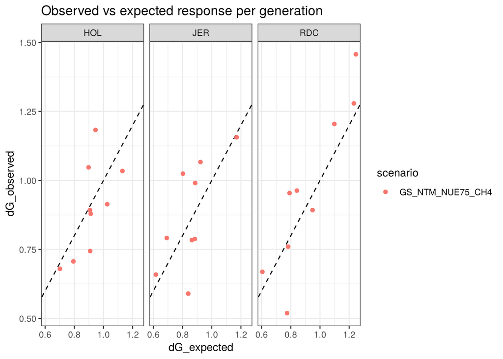

```r
ggplot(beq[!is.na(dG_observed)], aes(dG_expected, dG_observed, colour = scenario)) +
  geom_abline(lty = 2) + geom_point() + facet_wrap(~breed) + theme_bw() +
  labs(title = "Observed vs expected response per generation")
```

# 7 Population performance over time (burn-in + selection)

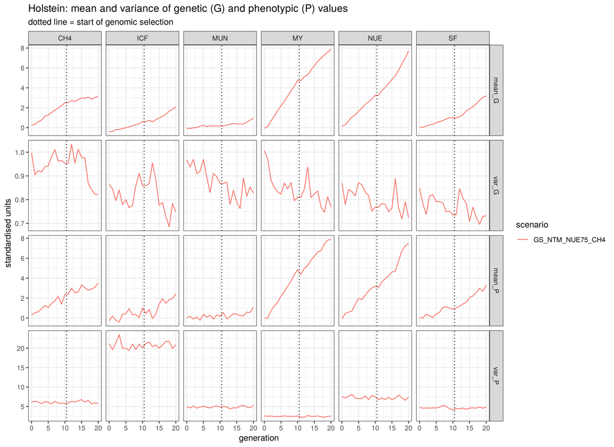

```r
tr_all <- rbind(
  rbindlist(lapply(scen, function(s) cbind(scenario = s, trend0))),
  trend, fill = TRUE)
long <- melt(tr_all[trait %in% c("MY", "NUE", "MUN", "SF", "CH4", "ICF")],
             id.vars = c("scenario", "generation", "breed", "trait"))
ggplot(long[breed == "HOL"], aes(generation, value, colour = scenario)) +
  geom_line() + geom_vline(xintercept = burn_end + 0.5, lty = 3) +
  facet_grid(variable ~ trait, scales = "free_y") + theme_bw() +
  labs(title = "Holstein: mean and variance of genetic (G) and phenotypic (P) values",
       subtitle = "dotted line = start of genomic selection", y = "standardised units")
```

```r
kable(dcast(trend[trait %in% c("NUE", "MUN", "MY", "SF", "CH4") & generation == max(generation)],
            breed + trait ~ scenario, value.var = "mean_G"), digits = 3,
      caption = "Mean genetic value in the final generation (genetic SD units of the founders)")
```

Mean genetic value in the final generation (genetic SD units of the founders)

| breed | trait | GS_NTM_NUE75_CH4 |
| --- | --- | --- |
| HOL | CH4 | 3.145 |
| HOL | MUN | 0.926 |
| HOL | MY | 7.902 |
| HOL | NUE | 7.742 |
| HOL | SF | 3.190 |
| JER | CH4 | 2.612 |
| JER | MUN | 0.926 |
| JER | MY | 7.899 |
| JER | NUE | 7.676 |
| JER | SF | 4.682 |
| RDC | CH4 | 2.141 |
| RDC | MUN | 0.237 |
| RDC | MY | 8.620 |
| RDC | NUE | 6.390 |
| RDC | SF | 3.529 |

# 8 Multi-trait information over cycles: correlation with the index

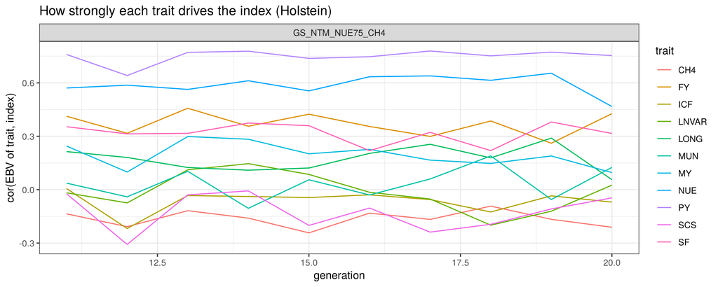

```r
if (nrow(idx) == 0) cat("No genomic EBVs in this run (PHENO scenario only) - nothing to show.\n") else print(
ggplot(idx[breed == "HOL"], aes(generation, cor_EBV_index, colour = trait)) +
  geom_line() + facet_wrap(~scenario) + theme_bw() +
  labs(y = "cor(EBV of trait, index)", title = "How strongly each trait drives the index (Holstein)"))
```

```r
if (nrow(idx)) kable(dcast(idx[, .(acc = mean(acc_trait)), by = .(scenario, trait)], trait ~ scenario,
            value.var = "acc"), digits = 3, caption = "Mean accuracy of genomic EBV per trait")
```

Mean accuracy of genomic EBV per trait

| trait | GS_NTM_NUE75_CH4 |
| --- | --- |
| CH4 | 0.393 |
| FY | 0.438 |
| ICF | 0.251 |
| LNVAR | 0.425 |
| LONG | 0.279 |
| MUN | 0.393 |
| MY | 0.466 |
| NUE | 0.338 |
| PY | 0.429 |
| SCS | 0.304 |
| SF | 0.391 |

# 9 Inbreeding and the mating plan

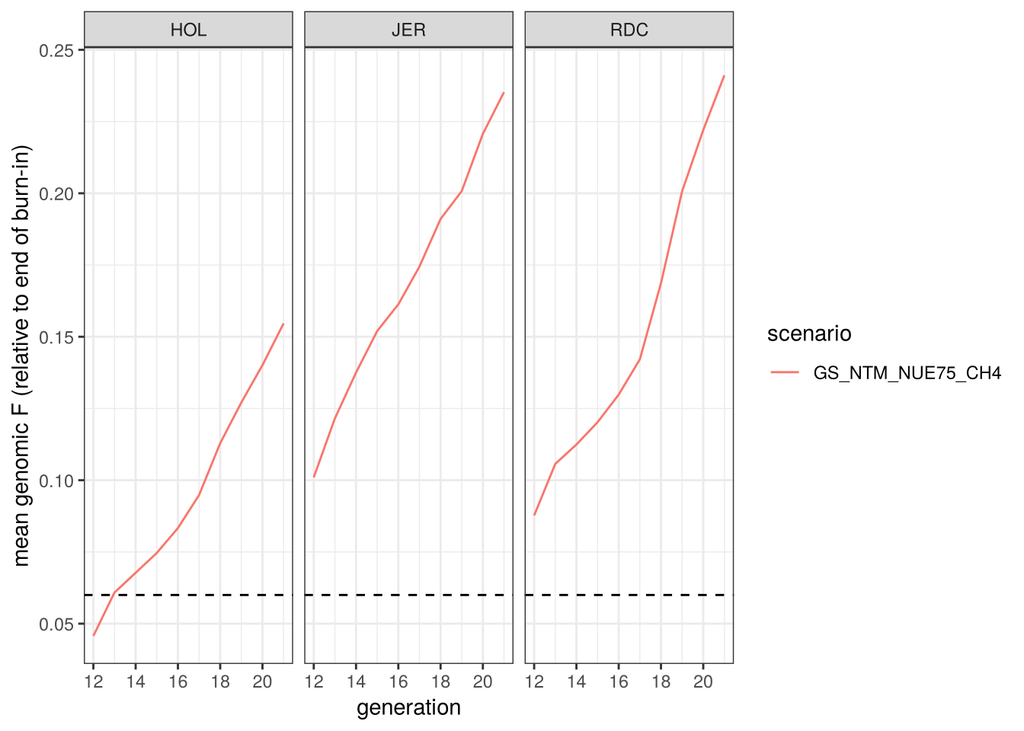

```r
ggplot(Fdt, aes(generation, F_genomic, colour = scenario)) + geom_line() +
  geom_hline(yintercept = params$f_max, lty = 2) + facet_wrap(~breed) + theme_bw() +
  labs(y = "mean genomic F (relative to end of burn-in)")
```

```r
kable(Fdt[generation == max(generation)], digits = 4)
```

| scenario | generation | breed | F_genomic | expected_F |
| --- | --- | --- | --- | --- |
| GS_NTM_NUE75_CH4 | 21 | HOL | 0.1547 | 0.1535 |
| GS_NTM_NUE75_CH4 | 21 | RDC | 0.2411 | 0.2334 |
| GS_NTM_NUE75_CH4 | 21 | JER | 0.2353 | 0.2183 |

## 9.1 Optimum contribution selection diagnostics

```r
if (nrow(ocs)) {
  kable(ocs, digits = 4, caption = "OCS per generation: coancestry target vs achieved, feasibility, sires used, largest sire share")
  print(ggplot(ocs, aes(generation)) + geom_line(aes(y = C_target), lty = 2) +
          geom_line(aes(y = C_achieved, colour = breed)) + theme_bw() +
          labs(y = "group coancestry of parents", subtitle = "dashed = target path"))
} else cat("OCS scenario not run in this render.\n")
```

```
## OCS scenario not run in this render.
```

# 10 Recommended mating plan (final generation)

```r
kable(Fdt[scenario == "GS_NTM_NUE35_MATE", .(mean_expected_F = mean(expected_F)), by = breed], digits = 4)
```

| breed | mean_expected_F |
| --- | --- |

# 11 Save

```r
tag <- paste(scen, collapse = "_")
if (length(scen) == 1 && is_ocs(scen) && params$ocs_dF != 0.005) tag <- lab
if (params$eval_model != "auto") tag <- paste0(tag, "_", eval_model)   # model-test runs carry the model name
if (params$rep_id > 0) tag <- paste0(tag, "_rep", params$rep_id)
if (nrow(ev_time)) fwrite(ev_time, file.path(params$sim_dir, paste0("gs_eval_time_", tag, ".csv")))
fwrite(trend, file.path(params$sim_dir, paste0("gs_trend_", tag, ".csv")))
fwrite(beq,   file.path(params$sim_dir, paste0("gs_breeders_equation_", tag, ".csv")))
fwrite(idx,   file.path(params$sim_dir, paste0("gs_index_correlations_", tag, ".csv")))
fwrite(Fdt,   file.path(params$sim_dir, paste0("gs_inbreeding_", tag, ".csv")))
if (nrow(ocs)) fwrite(ocs, file.path(params$sim_dir, paste0("gs_ocs_", tag, ".csv")))
fwrite(data.table(trait = traits, sdA0 = sdA0), file.path(params$sim_dir, "gs_sdA0.csv"))   # standardisation constants (same in every run)
cat("Run time:", format(Sys.time() - t0), "\n")
```

```
## Run time: 24.87932 mins
```